# Exploring Climate-Driven Changes in Sea Surface Temperature (SST) in the Southern Ocean

Author: Md Rony Golder (https://ronygolderku.netlify.app/), Afra Tanjim Shammi

### Overview

The Southern Ocean, surrounding the continent of Antarctica, plays a crucial role in global climate regulation. Studying the dynamics of Sea Surface Temperature (SST) in this region provides valuable insights into climate-driven changes over time. In this Jupyter notebook, we delve into a comprehensive analysis of 32 years (1991-2022) of remote sensing data to understand the key features of SST in the Southern Ocean

### Key Objectives

Our primary objectives encompass a multifaceted exploration of SST dynamics, spanning mean SST visualization, trend analysis, and Empirical Orthogonal Function (EOF) analysis. First and foremost, we seek to unveil the overarching patterns and temperature distributions in the Southern Ocean by visualizing the mean SST. Subsequently, we delve into trend analysis, deciphering the rate of change in SST per year over the extensive 32-year duration. Lastly, we employ EOF analysis to discern spatial patterns and modes of variability in SST..

## Dependencies

**Click to expand**

- **[NumPy](https://numpy.org/):** NumPy is a fundamental package for scientific computing with Python, enabling efficient manipulation of multi-dimensional arrays.
- **[Xarray](http://xarray.pydata.org/en/stable/):** Xarray simplifies the handling of NetCDF files in Python. It introduces labels, such as dimensions, coordinates, and attributes, enhancing the manipulation of arrays and facilitating a more intuitive and error-resistant developer experience.
- **[Matplotlib](https://matplotlib.org/):** Matplotlib is a versatile Python 2D plotting library that produces high-quality figures, essential for creating visualizations in scientific analyses.
- **[Cartopy](https://scitools.org.uk/cartopy/docs/latest/):** Cartopy is a Python library dedicated to map creation and geospatial data analysis. It provides tools for plotting maps, making it invaluable for visualizing geographical data.
- **[Pandas](https://pandas.pydata.org/docs/):** Pandas is a powerful library for data manipulation and analysis in Python. It offers easy-to-use data structures and tools, making it a go-to choice for handling structured data.
- **[XEOFs](https://xeofs.readthedocs.io/en/stable/):** XEOFs provides tools for performing Empirical Orthogonal Function (EOF) analysis, a crucial technique for identifying spatial patterns and modes of variability in geospatial datasets.
- **[Cmaps](https://github.com/SciTools/cmaps):** Cmaps provides a collection of colormaps for use in scientific visualizations, enhancing the options available for representing data with distinct coor schemes.

**General Note 1**: Execute each cell through the button from the top MENU (or keyboard shortcut `Shift` + `Enter`).  
**General Note 2**: If, for any reason, the kernel is not working anymore, in the top MENU, click on the button. Then, in the top MENU, click on "Run" and select "Run All Above Selected Cell".

```python
import sys
print(sys.executable)
```

```
/home/ubuntu/miniconda3/bin/python
```

```python
%run antarctic_map.py
```

```python
import cartopy
import cartopy.crs as ccrs
import cartopy.feature as cfeature
import matplotlib.pyplot as plt
import matplotlib.colors as colors
import matplotlib.colors as mcolors
import numpy as np
import pandas as pd
import matplotlib.path as mpath
import matplotlib.patches as mpatches
import matplotlib.dates as mdates
import xarray as xr
from matplotlib.lines import Line2D
import cmaps
# To avoid warning messages
import warnings
warnings.filterwarnings('ignore')
```

## Data Source

The data used in this analysis is sourced from the NOAA Optimum Interpolation (OI) Sea Surface Temperature (SST) V2 dataset, which can be downloaded from [NOAA PSL](https://downloads.psl.noaa.gov/Datasets/noaa.oisst.v2/).

### Temporal Coverage:

SST data from the dataset has been selected for the period spanning from 1991 to 2022.

```python
ds = xr.open_dataset('./noaa_oisst.nc')
ds
```

```
<xarray.Dataset>
Dimensions:  (lat: 55, lon: 360, time: 384)
Coordinates:
  * lat      (lat) float32 -30.5 -31.5 -32.5 -33.5 ... -81.5 -82.5 -83.5 -84.5
  * lon      (lon) float32 -179.5 -178.5 -177.5 -176.5 ... 177.5 178.5 179.5
  * time     (time) datetime64[ns] 1991-01-01 1991-02-01 ... 2022-12-01
Data variables:
    sst      (time, lat, lon) float32 ...
```

```python
ds_mean = ds.mean(dim='time')
ds_mean
```

```
<xarray.Dataset>
Dimensions:  (lat: 55, lon: 360)
Coordinates:
  * lat      (lat) float32 -30.5 -31.5 -32.5 -33.5 ... -81.5 -82.5 -83.5 -84.5
  * lon      (lon) float32 -179.5 -178.5 -177.5 -176.5 ... 177.5 178.5 179.5
Data variables:
    sst      (lat, lon) float32 20.68 20.64 20.61 20.6 20.62 ... nan nan nan nan
```

## Mean Sea Surface Temperature Visualization

The generated plot provides a visual representation of the mean sea surface temperature (SST) in the Southern Ocean. Key features of the visualization include:

- **Projection:** The map is presented in the South Polar Stereographic projection, allowing for a focused view of the Southern Ocean.
- **Color Map:** The color map used for the contour plot is 'BlAqGrYeOrRe' from the cmaps library, which helps in conveying variations in sea surface temperatures effectively.
- **Temperature Levels:** The contour levels are set at 40 intervals, providing a detailed representation of temperature variations across the region.
- **Color Bar:** The horizontal color bar located at the bottom of the plot provides a reference for interpreting temperature values. The ticks on the color bar are set at 2-degree intervals.
- **Temperature Range:** The color map spans from -2°C to 24°C, allowing for a clear visualization of the temperature distribution.
- **Font Settings:** The font family is set to 'serif', and the font size is adjusted for clarity and aesthetics.

The plot is generated using the matplotlib and cartopy libraries, facilitating the creation of informative and visually appealing visualizations of mean sea surface temperatures in the Southern Ocean.

## Geographical Delineations and Oceanic Features

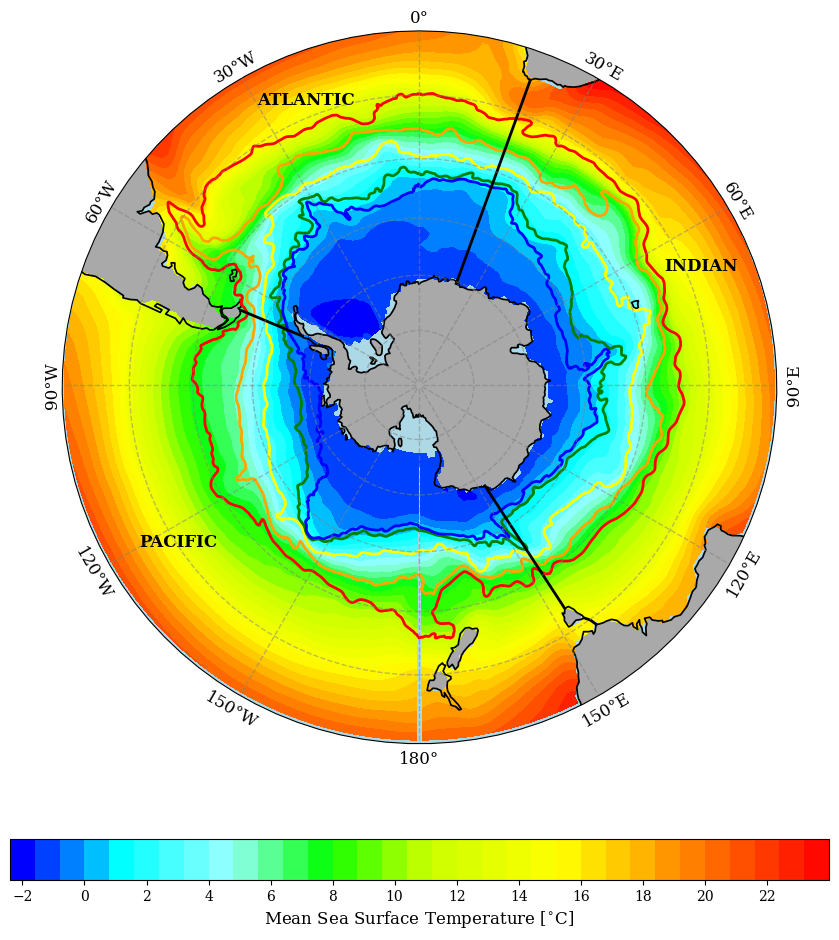

```python
plt.rcParams["font.family"] = "serif"
plt.rcParams['font.size'] = 12

# Set the figure size to 15x18 inches
plt.figure(figsize=(12, 10))
ax = plt.subplot(1, 1, 1, projection=ccrs.SouthPolarStereo())
ax = plt.gca()
ax = antarctic_map(ax)

im = ax.contourf(ds_mean.lon, ds_mean.lat, ds_mean.sst.values, cmap=cmaps.BlAqGrYeOrRe,transform=ccrs.PlateCarree(), levels=40,
                           vmin=-2,vmax=24)
cbar_ticks = np.arange(-2, 24, 2)
# Create the color bar
cbar = plt.colorbar(im, ax=ax, shrink=0.7, pad=0.1, orientation='horizontal', extendrect=True,
                        ticks=cbar_ticks)
cbar.ax.tick_params(labelsize=10)
cbar.ax.set_xlabel('Mean Sea Surface Temperature [$^{\circ}$C]')
plt.rcParams['font.size'] = 10
plt.rcParams["font.family"] = "serif"

# Show the plot
plt.tight_layout()
```

```python
ds_average=ds.mean('lat').mean('lon')
ds_average
```

```
<xarray.Dataset>
Dimensions:  (time: 384)
Coordinates:
  * time     (time) datetime64[ns] 1991-01-01 1991-02-01 ... 2022-12-01
Data variables:
    sst      (time) float32 8.419 8.852 8.62 7.974 ... 5.656 5.929 6.531 7.513
```

## Monthly Variation of Sea Surface Temperature in the Southern Ocean

The code generates a line plot illustrating the monthly variation of sea surface temperature (SST) in the Southern Ocean. Key aspects of the plot include:

- **Figure Size:** The figure size is set to 12 inches in width and 3 inches in height, ensuring a well-proportioned and readable visualization.
- **Line Plot:** The main plot consists of a line chart where the x-axis represents time (presumably in months), and the y-axis represents the average sea surface temperature.
- **Color:** The line is colored green ('tab:green') for better visibility against the background.
- **Title:** The title of the plot is set as "Average surface sea surface temperature," providing a clear indication of the content being visualized.

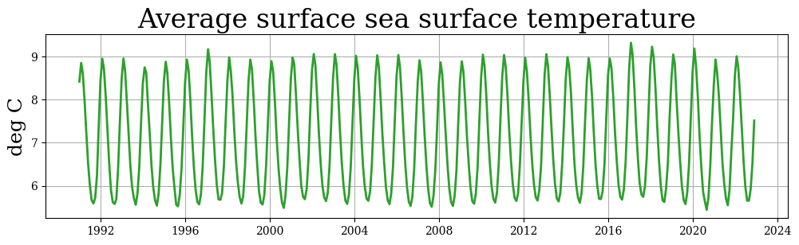

```python
f = plt.figure(figsize=(12,3))
plt.plot(ds_average.time,ds_average.sst,c='tab:green',linewidth=2)
plt.title("Average surface sea surface temperature",fontsize=24)
plt.grid()
plt.ylabel("deg C",fontsize=18)
```

```python
sst_dg = ds.sst
```

```python
mean_monthly = sst_dg.mean(["lat", "lon"])
monthly = mean_monthly.to_dataframe(name = "Sea Surface Temperature")
monthly
```

| time | Sea Surface Temperature |
| --- | --- |
| 1991-01-01 | 8.441180 |
| 1991-02-01 | 8.893950 |
| 1991-03-01 | 8.659395 |
| 1991-04-01 | 8.006268 |
| 1991-05-01 | 7.260805 |
| ... | ... |
| 2022-08-01 | 5.686434 |
| 2022-09-01 | 5.680212 |
| 2022-10-01 | 5.949692 |
| 2022-11-01 | 6.560202 |
| 2022-12-01 | 7.553276 |

384 rows × 1 columns

```python
mean_annual = mean_monthly.groupby("time.year").mean()
annual = mean_annual.to_dataframe(name = "Sea Surface Temperature")
annual
```

| year | Sea Surface Temperature |
| --- | --- |
| 1991 | 7.046715 |
| 1992 | 7.076308 |
| 1993 | 7.069555 |
| 1994 | 7.039147 |
| 1995 | 7.028982 |
| 1996 | 7.067163 |
| 1997 | 7.180557 |
| 1998 | 7.094031 |
| 1999 | 7.051922 |
| 2000 | 7.037421 |
| 2001 | 7.179705 |
| 2002 | 7.152956 |
| 2003 | 7.116798 |
| 2004 | 7.120559 |
| 2005 | 7.123215 |
| 2006 | 7.097449 |
| 2007 | 7.026897 |
| 2008 | 7.011178 |
| 2009 | 7.065862 |
| 2010 | 7.139771 |
| 2011 | 7.145399 |
| 2012 | 7.104859 |
| 2013 | 7.149990 |
| 2014 | 7.139027 |
| 2015 | 7.120039 |
| 2016 | 7.164068 |
| 2017 | 7.303835 |
| 2018 | 7.246789 |
| 2019 | 7.142502 |
| 2020 | 7.098009 |
| 2021 | 7.144738 |
| 2022 | 7.157745 |

## Monthly Anomaly Calculation for Sea Surface Temperature (SST)

The code calculates monthly anomalies for the sea surface temperature (SST) dataset. Key steps in the process include:

- **Monthly Climatology:** The sea surface temperature dataset (`sst_dg`) is grouped by month (`time.month`), and the mean temperature for each month is computed. This results in a monthly climatology representing the average SST for each month across the entire dataset.
- **Anomaly Calculation:** The original SST dataset is then grouped by month, and the computed monthly climatology is subtracted from each corresponding monthly value. This subtraction yields an anomaly dataset, capturing deviations from the average monthly SST.
- **Mean Monthly Anomaly:** The mean anomaly is calculated by averaging across latitudinal and longitudinal dimensions, resulting in a single anomaly value for each month.

```python
monthly_climatology = sst_dg.groupby("time.month").mean("time")
anomaly = sst_dg.groupby('time.month') - monthly_climatology

# Calculate the monthly anomaly
mean_monthly_anomaly = anomaly.mean(["lat", "lon"])
monthly_anomaly = mean_monthly_anomaly.to_series()
```

## Regression Analysis for Annual Rate of Change in Sea Surface Temperature (SST)

In this section, a regression analysis is performed to assess the annual rate of change in sea surface temperature (SST) for each pixel in the dataset. The key steps include:

- **Anomaly Polynomial Fit:** The previously calculated monthly anomalies (`anomaly`) are subjected to a polynomial fit with a degree of 1 along the "time" dimension. This fit aims to capture the linear trend in SST anomalies over time.
- **Regression Coefficients:** The coefficients obtained from the polynomial fit represent the slope and intercept of the linear regression equation. The slope corresponds to the annual rate of change in SST.
- **Total Climatology Calculation:** The mean SST climatology across all time steps is computed (`total_climatology`). This value is used to normalize the regression coefficients.
- **Annual Rate of Change Calculation:** The annual rate of change in SST for each pixel is determined by dividing the scaled slope (multiplied by 12 for annualization) by the sum of the intercept and total climatology.

This analysis provides insights into how sea surface temperatures are changing annually for each geographical pixel. The regression results offer a quantitative measure of the trends, facilitating the identification of regions experiencing significant warming or cooling trends over the analyzed period.

```python
anomaly = anomaly.assign_coords(time = ("time", np.arange(0, anomaly.shape[0])))
anomaly = anomaly.reset_coords(drop = True)

# Apply a linear regression where x = time and y = sst anomaly for each pixel
regression = anomaly.polyfit("time", 1, skipna = True, full = True)

# Calculate the annual rate of change in sst for each pixel
total_climatology = sst_dg.mean("time")
pixel_rates = (regression.polyfit_coefficients.sel(degree = 1) * 12) / (regression.polyfit_coefficients.sel(degree = 0) + total_climatology)
```

## Spatial Representation of Annual Rate of Change in Sea Surface Temperature (SST)

The code snippet visualizes the spatial distribution of the annual rate of change in sea surface temperature (SST) across the dataset. The main steps include:

- **Pixel Rates Calculation:** Using the previously obtained regression coefficients, the annual rate of change in SST for each geographical pixel is calculated. These pixel rates represent the magnitude and direction of temperature trends on an annual basis.
- **Visualization with Pcolormesh:** The `pcolormesh` function from Matplotlib is employed to create a color-coded representation of the calculated pixel rates on a map. The color scale reflects the intensity of temperature change, with specific colormap settings (`cmap`, `vmin`, and `vmax`) defining the color range.
- **Color Bar Creation:** A horizontal color bar is added to the plot, providing a reference for the color-coding and indicating the corresponding magnitude of the annual SST rate of change. The color bar is positioned at the bottom of the plot for easy interpretation.

This visualization enhances the understanding of spatial patterns in annual SST trends, enabling the identification of regions with pronounced warming or cooling trends over the analyzed period.

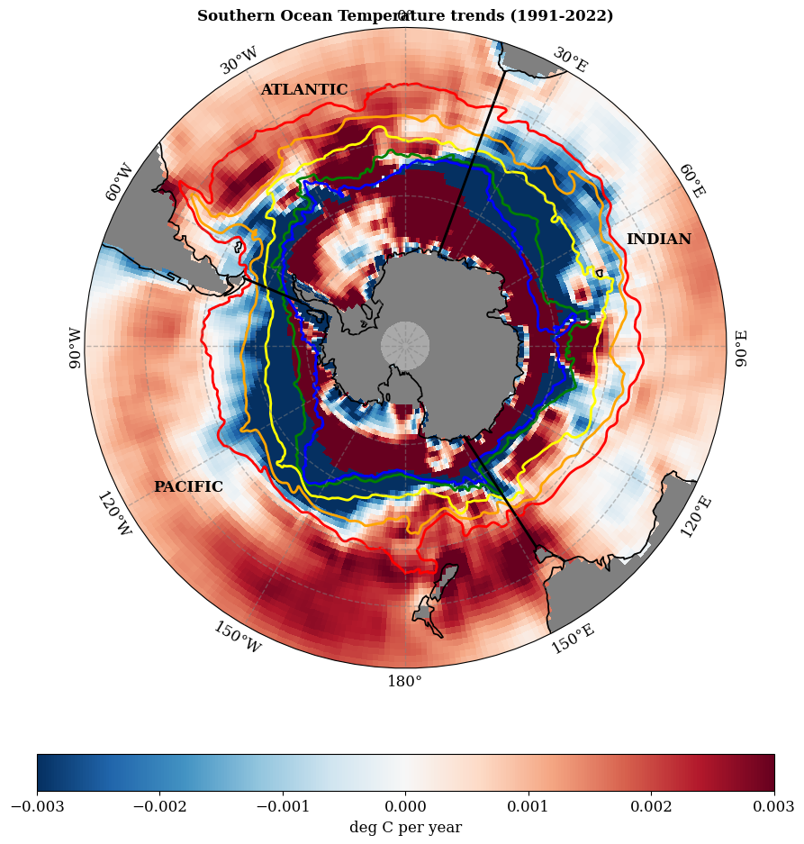

```python
plt.rcParams["font.family"] = "serif"
plt.rcParams['font.size'] = 12

# Set the figure size to 15x18 inches
plt.figure(figsize=(12, 10))
ax = plt.subplot(1, 1, 1, projection=ccrs.SouthPolarStereo())
ax = plt.gca()
ax = antarctic_map(ax)

colormap = plt.cm.get_cmap('RdBu_r').copy()
colormap.set_bad(color='gray')

im = ax.pcolormesh(pixel_rates.lon, pixel_rates.lat, pixel_rates.values, cmap=colormap,
                   vmin=-0.003, vmax=0.003, transform=ccrs.PlateCarree())

# Create the color bar
cbar = plt.colorbar(im, ax=ax, shrink=0.7, pad=0.1, orientation='horizontal')
cbar.ax.set_xlabel('deg C per year')
plt.rcParams['font.size'] = 10
plt.rcParams["font.family"] = "serif"
ax.set_title("Southern Ocean Temperature trends (1991-2022)", fontweight='bold')
# Show the plot
plt.tight_layout()
```

```python
import scipy.stats as stats

# Apply a linear regression where x = time and y = chlor anomaly for each pixel
# Set the cov parameter to True to return the covariance matrix
regression = anomaly.polyfit("time", 1, skipna = True, full = True, cov = True)

# Get the coefficients and the covariance matrix from the regression
coef = regression.polyfit_coefficients
cov = regression.polyfit_covariance

# Get the degrees of freedom from the anomaly shape
dof = anomaly.shape[0] - 2
```

```python
se = np.sqrt(np.diagonal(cov, axis1=0, axis2=1)).transpose(2,0,1)

# Get the t values of the coefficients by dividing them by the standard errors
t = coef / se
p = 2 * (1 - stats.t.cdf(np.abs(t), dof))
p
```

```
array([[[ 0.,  0.,  0., ...,  0.,  0.,  0.],
        [ 0.,  0.,  0., ...,  0.,  0.,  0.],
        [ 0.,  0.,  0., ...,  0.,  0.,  0.],
        ...,
        [nan, nan, nan, ..., nan, nan, nan],
        [nan, nan, nan, ..., nan, nan, nan],
        [nan, nan, nan, ..., nan, nan, nan]],

       [[ 0.,  0.,  0., ...,  0.,  0.,  0.],
        [ 0.,  0.,  0., ...,  0.,  0.,  0.],
        [ 0.,  0.,  0., ...,  0.,  0.,  0.],
        ...,
        [nan, nan, nan, ..., nan, nan, nan],
        [nan, nan, nan, ..., nan, nan, nan],
        [nan, nan, nan, ..., nan, nan, nan]]])
```

```python
coords = {
    "degree": [0, 1],  # Assuming 'degree' is the first dimension
    "latitude": ds.lat.values,    # Assuming 'y' corresponds to the second dimension
    "longitude": ds.lon.values     # Assuming 'x' corresponds to the third dimension
}

# Create the DataArray
p_xr = xr.DataArray(p, coords=coords)

# Now you can select p-values for the degree 1 term
p1 = p_xr.sel(degree=1)
p1
```

```
<xarray.DataArray (latitude: 55, longitude: 360)>
array([[ 0.,  0.,  0., ...,  0.,  0.,  0.],
       [ 0.,  0.,  0., ...,  0.,  0.,  0.],
       [ 0.,  0.,  0., ...,  0.,  0.,  0.],
       ...,
       [nan, nan, nan, ..., nan, nan, nan],
       [nan, nan, nan, ..., nan, nan, nan],
       [nan, nan, nan, ..., nan, nan, nan]])
Coordinates:
    degree     int64 1
  * latitude   (latitude) float32 -30.5 -31.5 -32.5 -33.5 ... -82.5 -83.5 -84.5
  * longitude  (longitude) float32 -179.5 -178.5 -177.5 ... 177.5 178.5 179.5
```

## Mapping the Significance of SST Trend

In this visualization, we map the significance of the sea surface temperature (SST) trend in the Southern Ocean. The color scheme is designed to convey the significance level, where green indicates a significant trend and blue represents a non-significant trend at a 95% confidence level.

The significance is determined by calculating the trend and its significance for each pixel in the SST data. The resulting map provides a spatial representation of regions where SST trends are statistically significant, aiding in the identification of areas with notable temperature changes.

The custom labels on the color bar further emphasize the interpretation: 'Significant' for green and 'Non-significant' for blue.

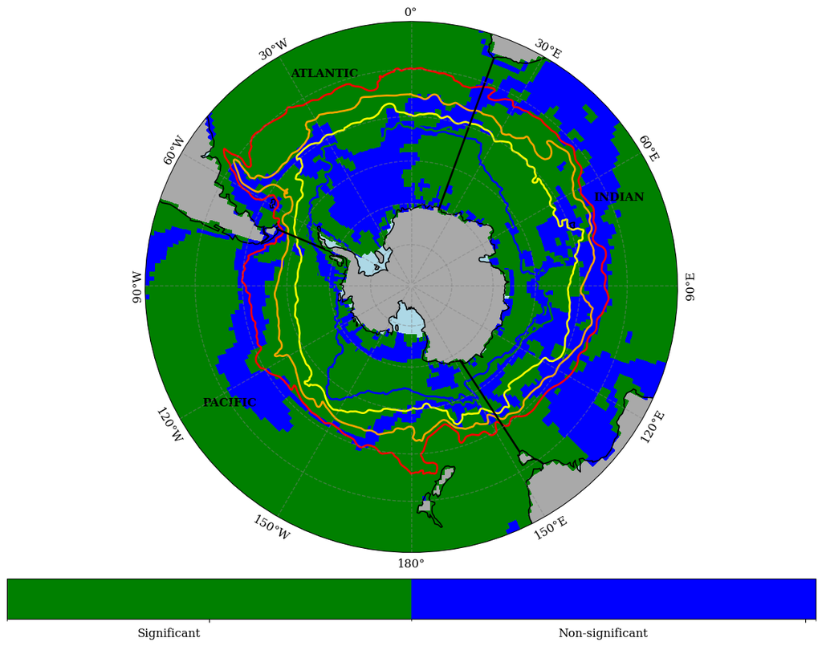

```python
plt.rcParams["font.family"] = "serif"
plt.rcParams['font.size'] = 12

# Set the figure size to 15x18 inches
plt.figure(figsize=(12, 10))
ax = plt.subplot(1, 1, 1, projection=ccrs.SouthPolarStereo())
ax = plt.gca()
ax = antarctic_map(ax)
colors = ['green', 'blue']
# Create a custom colormap using ListedColormap
cmap = mcolors.ListedColormap(colors)
# Create a custom normalization for the colormap
norm = mcolors.BoundaryNorm([0, 0.05, 1], cmap.N)
im = ax.pcolormesh(p1.longitude, p1.latitude, p1.values, cmap=cmap, norm=norm,transform=ccrs.PlateCarree())
# Create the color bar
cbar = plt.colorbar(im, ax=ax, shrink=1, pad=0.04, orientation='horizontal')
cbar.set_ticks([0.025, 0.975])
cbar.set_ticklabels([])

# Define custom labels and positions for the colorbar text labels
labels = ['Significant', 'Non-significant']
positions = [0.02, 0.5]

# Add the text labels to the colorbar
for label, pos in zip(labels, positions):
    cbar.ax.text(pos, -0.2, label, ha='center', va='top', fontsize=12)
plt.tight_layout()
```

# Carry out EOF analysis

In the realms of statistics and signal processing, empirical orthogonal function (EOF) analysis is a technique employed to decompose a signal or dataset into orthogonal basis functions, derived directly from the data. This method bears resemblance to conducting a principal components analysis (PCA) on the data, with the key distinction that EOF analysis uncovers both temporal projections and spatial patterns simultaneously. In the context of geophysics, the term EOF is often used interchangeably with geographically weighted principal components analysis (PCAs) (source: https://en.wikipedia.org/wiki/Empirical_orthogonal_functions). The spatial patterns, termed EOFs, can be conceptualized as basis functions with respect to variance, while the associated temporal projections represent the principal components (PCs), serving as the temporal coefficients corresponding to the EOF patterns.

```python
from xeofs.models import EOF
```

```python
model = EOF(n_modes=3, use_coslat=True)
model.fit(sst_dg, dim="time")
```

```
<xeofs.models.eof.EOF at 0x7f2cf2602d70>
```

```python
expvar = model.explained_variance()
expvar_ratio = model.explained_variance_ratio()
components = model.components()
scores = model.scores()
```

```python
print("Explained variance: ", expvar.round(0).values)
print("Relative: ", (expvar_ratio * 100).round(1).values)
```

```
Explained variance:  [19441.   350.   258.]
Relative:  [87.8  1.6  1.2]
```

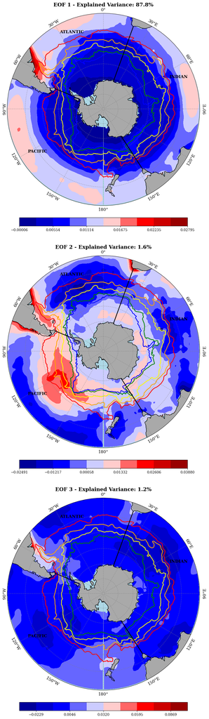

```python
plt.figure(figsize=(10, 30))

for i in range(len(components)):
    ax = plt.subplot(3, 1, i+1, projection=ccrs.SouthPolarStereo())
    ax = plt.gca()
    ax = antarctic_map(ax)
    clevs = np.linspace(np.min(components[i][:, :].squeeze()), np.max(components[i][:, :].squeeze()), 11)
    im = ax.contourf(components[i].lon, components[i].lat, components[i].values, clevs, cmap=cmaps.BlWhRe,
                    transform=ccrs.PlateCarree())
    cbar = plt.colorbar(im, ax=ax, shrink=0.7, pad=0.05, orientation='horizontal', extendrect=True)
    cbar.ax.tick_params(labelsize=10)
    ax.set_title(f'EOF {i+1} - Explained Variance: {(expvar_ratio[i].values * 100).round(1)}%', fontweight='bold', fontsize=15, pad=20)

plt.rcParams['font.size'] = 10
plt.rcParams["font.family"] = "serif"

plt.tight_layout()
```

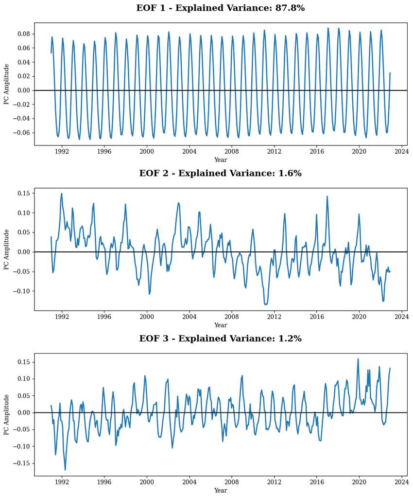

```python
plt.figure(figsize=(10, 12))

for i in range(len(scores)):
    ax = plt.subplot(3, 1, i + 1)
    # Plot the line chart for scores
    time = scores.time.values
    ax.plot(time, scores[i].values, linewidth=2)

    # Customize the plot
    ax.axhline(0, color='k')
    ax.set_xlabel('Year')
    ax.set_ylabel('PC Amplitude')

    ax.set_title(f'EOF {i+1} - Explained Variance: {(expvar_ratio[i].values * 100).round(1)}%', fontweight='bold', fontsize=15, pad=20)

# Adjust the top parameter to reduce the gap between charts and titles
plt.subplots_adjust(top=0.9)

plt.rcParams['font.size'] = 10
plt.rcParams["font.family"] = "serif"

plt.tight_layout()
```

Thanks for viewing this notebook